# Reading, Selected Hobo Temperature Logger

Chuck Burks

2023-04-28

## Read in Data

This document serves as a readable auto-reminder about how to fish necessary information out of a Hobotemp data file. Here we are examining a file from a walk-in environmental chamber that started to have worrisome heating issues.

It is necessary to play with the directories a bit to get the correct file and file location. That can be done using autocomplete features in R/RStudio. Most of the needed functions are loaded with the tidyverse mega-library. The clean_names() function of the janitor packages is also used to deal with messy default variable names.

```r
getwd()
```

```
## [1] "C:/Users/Charles.Burks/my_git/Work_misc/2023-02-09-read-hobo-dat"
```

```r
list.dirs()
```

```
## [1] "."             "./zarch-dat"   "./zarch-plots"
```

```r
dat_in <- read_csv("Queue 2 2023-04-28 07_10_43 PDT (Data PDT).csv",
                   show_col_types = FALSE)
```

```
## Warning: One or more parsing issues, call `problems()` on your data frame for details,
## e.g.:
##   dat <- vroom(...)
##   problems(dat)
```

```r
dat_in
```

```
## # A tibble: 22,939 × 7
##      `#` `Date-Time (PST/PDT)` `Ch: 1 - Temperature   (°C)` `Ch: 2 - RH   (%)`
##    <dbl> <chr>                                        <dbl>              <dbl>
##  1     1 02/07/2023 15:17:03                           27.1               45.1
##  2     2 02/07/2023 15:22:03                           26.4               41.7
##  3     3 02/07/2023 15:27:03                           26.2               45.3
##  4     4 02/07/2023 15:32:03                           26.1               48.9
##  5     5 02/07/2023 15:37:03                           26.2               51.4
##  6     6 02/07/2023 15:42:03                           26.2               53.9
##  7     7 02/07/2023 15:47:03                           26.3               56.0
##  8     8 02/07/2023 15:52:03                           26.3               58.1
##  9     9 02/07/2023 15:57:03                           26.4               59.2
## 10    10 02/07/2023 16:02:03                           26.5               59.9
## # ℹ 22,929 more rows
## # ℹ 3 more variables: `Dew Point   (°C)` <dbl>, `Host Connected` <lgl>,
## #   `End of File` <chr>
```

This throws a warning, but it works. Additional clean-up steps are applied

```r
dat_in <- clean_names(dat_in)
dat_in
```

```
## # A tibble: 22,939 × 7
##    number date_time_pst_pdt   ch_1_temperature_c ch_2_rh_percent dew_point_c
##     <dbl> <chr>                            <dbl>           <dbl>       <dbl>
##  1      1 02/07/2023 15:17:03               27.1            45.1        14.2
##  2      2 02/07/2023 15:22:03               26.4            41.7        12.4
##  3      3 02/07/2023 15:27:03               26.2            45.3        13.4
##  4      4 02/07/2023 15:32:03               26.1            48.9        14.6
##  5      5 02/07/2023 15:37:03               26.2            51.4        15.4
##  6      6 02/07/2023 15:42:03               26.2            53.9        16.2
##  7      7 02/07/2023 15:47:03               26.3            56.0        16.8
##  8      8 02/07/2023 15:52:03               26.3            58.1        17.4
##  9      9 02/07/2023 15:57:03               26.4            59.2        17.8
## 10     10 02/07/2023 16:02:03               26.5            59.9        18.1
## # ℹ 22,929 more rows
## # ℹ 2 more variables: host_connected <lgl>, end_of_file <chr>
```

```r
dat_in$date_time_pst_pdt <- as.POSIXct(mdy_hms(dat_in$date_time_pst_pdt))

dat_in <- dat_in %>%
  rename(deg_c = 3,
         rh = ch_2_rh_percent)

dat_in
```

```
## # A tibble: 22,939 × 7
##    number date_time_pst_pdt   deg_c    rh dew_point_c host_connected end_of_file
##     <dbl> <dttm>              <dbl> <dbl>       <dbl> <lgl>          <chr>
##  1      1 2023-02-07 15:17:03  27.1  45.1        14.2 NA             <NA>
##  2      2 2023-02-07 15:22:03  26.4  41.7        12.4 NA             <NA>
##  3      3 2023-02-07 15:27:03  26.2  45.3        13.4 NA             <NA>
##  4      4 2023-02-07 15:32:03  26.1  48.9        14.6 NA             <NA>
##  5      5 2023-02-07 15:37:03  26.2  51.4        15.4 NA             <NA>
##  6      6 2023-02-07 15:42:03  26.2  53.9        16.2 NA             <NA>
##  7      7 2023-02-07 15:47:03  26.3  56.0        16.8 NA             <NA>
##  8      8 2023-02-07 15:52:03  26.3  58.1        17.4 NA             <NA>
##  9      9 2023-02-07 15:57:03  26.4  59.2        17.8 NA             <NA>
## 10     10 2023-02-07 16:02:03  26.5  59.9        18.1 NA             <NA>
## # ℹ 22,929 more rows
```

Also examining the end of the file

```
## # A tibble: 6 × 7
##   number date_time_pst_pdt   deg_c    rh dew_point_c host_connected end_of_file
##    <dbl> <dttm>              <dbl> <dbl>       <dbl> <lgl>          <chr>
## 1  22934 2023-04-28 06:52:03  27.2  53.0        16.8 NA             <NA>
## 2  22935 2023-04-28 06:57:03  27.1  52.8        16.7 NA             <NA>
## 3  22936 2023-04-28 07:02:03  27.1  53.6        16.8 NA             <NA>
## 4  22937 2023-04-28 07:07:03  26.8  48.5        15.1 NA             <NA>
## 5  22938 2023-04-28 07:11:23  NA    NA          NA   NA             <NA>
## 6  22939 2023-04-28 07:12:03  26.6  46.5        14.2 NA             Logged
```

## Plot tempertures over the entire time frame

For Rmarkdown the graphic is not saved, but the code in the accompanying R script includes formatting suitable for a journal 1 column (half page width) format, in part because I think that also sizes well if sent on a cell phone.

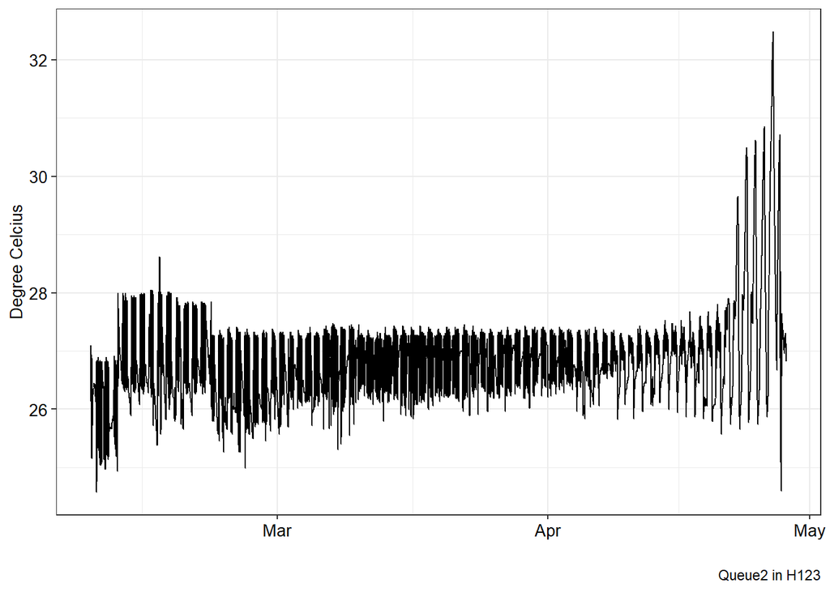

```r
ggplot(dat_in, aes(x = date_time_pst_pdt, y = deg_c)) +
  geom_line() +
  labs(x = "",
       y = "Degree Celcius",
       caption = "Queue2 in H123") +
  theme_csb_halfwidth1()
```

This output indicates that the temperature held steady for weeks, and started to spike more recently. I want to expand the X axis only within this time frame. I will use therefore use lubridate functions (loads with tidyverse) like month(), epiweek(), wday(), etc. to narrow the data set to times of interest. In this case we start by examining the last few epiweeks (weeks of the year, see ?epiweek)

```r
dat_in %>%
  mutate(wk = epiweek(date_time_pst_pdt)) %>%
  group_by(wk) %>%
  summarise(first_reading = min(date_time_pst_pdt)) %>%
  tail(.)
```

```
## # A tibble: 6 × 2
##      wk first_reading
##   <dbl> <dttm>
## 1    12 2023-03-19 00:02:03
## 2    13 2023-03-26 00:02:03
## 3    14 2023-04-02 00:02:03
## 4    15 2023-04-09 00:02:03
## 5    16 2023-04-16 00:02:03
## 6    17 2023-04-23 00:02:03
```

The data end with epiweek 17, and that captures the last 5 or so days of data.

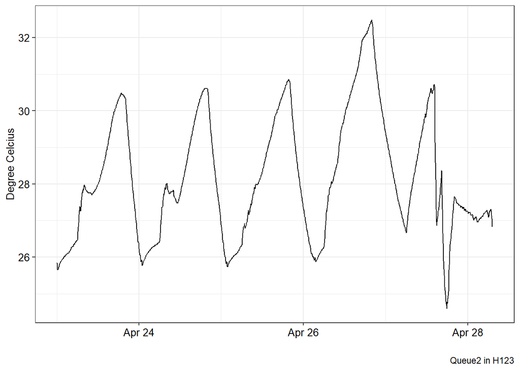

```r
dat_in %>%
  filter(epiweek(date_time_pst_pdt) == 17) %>%
  ggplot(., aes(x = date_time_pst_pdt, y = deg_c)) +
  geom_line() +
  labs(x = "",
       y = "Degree Celcius",
       caption = "Queue2 in H123") +
  theme_csb_halfwidth1()
```

So I have had the spiking problem for at least a week, but not a month. I can save these charts, pass them to somewhere that I can get them into the camera roll on my phone, and that way share them with maintenance and contractors in a quickly readable format. See “03script4-read-hobo-output-csv.R for the ggsave code.